# ESM 232 Final Project - Snowy Plover Management

### 3. Apply Habitat and Predator Management Functions

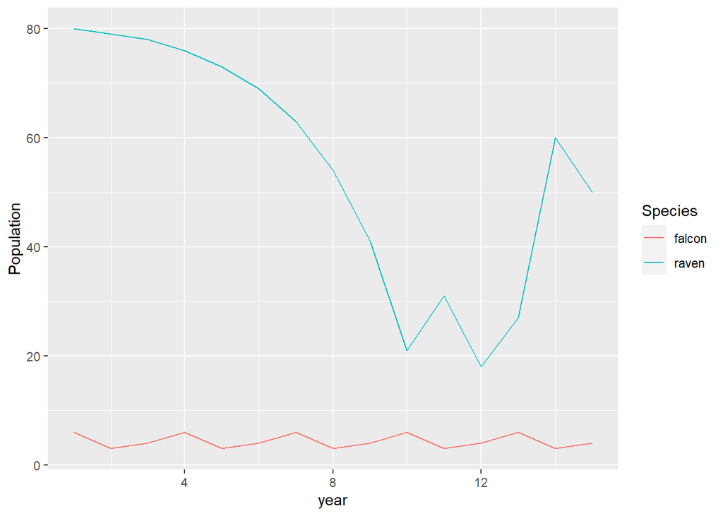

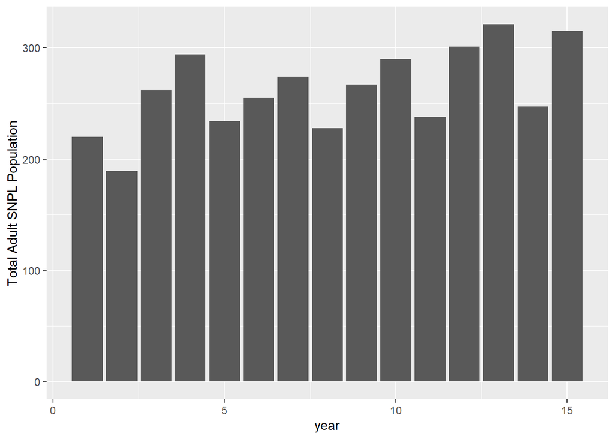

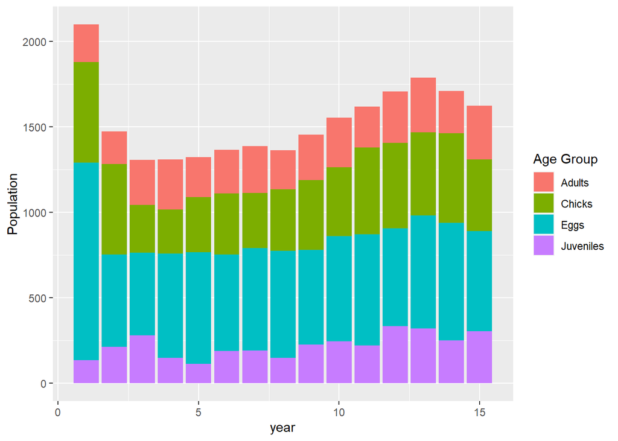

```r
# Output matrix of predator MGMT should go into snpl.R

source("../R/predator_mgmt.R")
source("../R/snpl.R")

F_adult = 5.25*0.6 # 1156/220 # 5.25 eggs per adult, M to F ratio of 0.6 (3 males to 2 females). represents number eggs per female; adjust for diff sex ratios
ini = c(1156,588,134,220)
n_years = 15
fert_snpl = c(0,0,0,F_adult)
surv_snpl = c(p_egg,p_chick,p_fledge,p_adult)
K = 1000
year = seq(from=1, to=n_years)


funding = 10 #in thousands?
raven_p = raven_pop(n_years, 80, 0.4, 200, mgmt_action = T, funding, rmv_eff= 4, min = 0.2, limit= 0.5) # inital population = 80 ravens
falcon_p = falcon_pop(n_years, 6, 0.3, 100, mgmt_action = T, funding, rmv_eff= 4, min = 0.3, limit = 0.8) # inital population = 6 falcons

tmp = list(egg_predation(raven_p), chick_predation(raven_p, falcon_p), juvenile_predation(falcon_p), adult_predation(falcon_p))
tmp2 = list(raven_p, falcon_p)
predation_matrix = tmp %>% unlist() %>% matrix(ncol=n_years, byrow = T) # row1= egg, row2= chick, row3=juvenile, row4=adult
predatorpop_matrix = tmp2 %>% unlist() %>% matrix(ncol=n_years, byrow = T) # row1= raven, row2=falcon
rm(tmp,tmp2)

area = habitat_area(1, init_mgmt = T, maint_mgmt = T, init_funding = 200, maint_funding = 30, n_time = n_years)



### This DOES WORK:
    ### Survivorship = 1-deathr
    ### deathr = 1 - survivorship

    ### deathr = predation + b = a * predator_pop + b
    ### deathr_0 = a * predator_0 + b

    ### let's assume 80% is gone by predation. and the other 20% is other cause.
    ### a = 0.8 * deathr_0/predator_pop0
    ### b = 0.2 * deathr_0 <- some kind of constant/intercept, but affected by snpl population change.
    ### b_t = 0.2 * deathr_0 * snpl_t/snpl_0

    ### deathr_t = a * predator_t + b_t
    ###          = 0.8 * deathr_0/predator_0 * predator_t + 0.2 * deathr_0 * snpl_t/snpl_0

    ### Survivorship_t = 1 - deathr_t
    ###                = 1- (0.8 * deathr_0/predator_0 * predator_t) - 0.2 * deathr_0 * total_t/total_0

### With survivorship, not deathrate. Use 25-year mean values for hatch and fledge rate, and mean estimate for first winter and adult survival.
p_egg = 45.9/100 # Hatch rate
p_chick = 36.3/100 # Fledge rate
p_fledge = 33/100 # First Winter Survival
p_adult = 66/100 # Adult survivorship
surv_snpl = c(p_egg,p_chick,p_fledge,p_adult)

snpl_popk3=snpl_pop3(fert_snpl, surv_snpl, ini, n_years, K, predatorpop_matrix, area) # Test purpose
snpl_tot3 = cbind.data.frame(year=year, adult_pop=snpl_popk3$pop_structure[4,])



# Plot all results by year
{
  p0 <- ggplot()+
    geom_line(aes(seq(1, ncol(predatorpop_matrix)),predatorpop_matrix[2,], color="falcon"))+
    geom_line(aes(seq(1, ncol(predatorpop_matrix)),predatorpop_matrix[1,], color="raven"))+
    labs(y="Population", x="year", color ="Species")

  p1<-ggplot(snpl_tot3, aes(year, adult_pop)) +
         geom_col() +
         labs(y="Total Adult SNPL Population")

  snpl_ages3 = cbind.data.frame(year=year, t(snpl_popk3$pop_structure))
  snpl_agesl3 = snpl_ages3 %>%
  gather(key="agecat", value="pop",-year) %>%
  mutate(age = case_when(agecat == "1" ~ "Eggs",
                         agecat == "2" ~ "Chicks",
                         agecat == "3" ~ "Juveniles",
                         agecat == "4" ~ "Adults"))

  p2<-ggplot(snpl_agesl3, aes(year, pop, fill=age)) +
  geom_col() +
  labs(y="Population", fill="Age Group")

  show(p0)
  show(p1)
  show(p2)
}
```

The Habitat Restoration Submodel influences annual plover fecundity by determining how much habitat is available for nesting. Funding for initial restoration and restoration maintenance is incorporated into the model. Greater funding for habitat restoration should translate into more habitat available for nesting and increased plover productivity. The Predator Management Submodel comprises separate lethal and non-lethal removal actions for ravens and peregrine falcons, respectively. Each of these predators target different plover life stages and are also subject to their own management laws. The peregrine falcons are protected under the Endangered Species Act, while ravens are not. These submodels also incorporate funding for the management strategy and whether or not the management actions are conducted. The model calculations for the predator management follow a modified exponential growth model where the predator population will grow unless checked by the management action or the population carrying capacity. The raven management model then influences egg and chick survival probability, while the falcon management model alters juvenile and adult survival. Since falcon management does not permanently remove the predator, a minimum limit was set so that the population never falls below that threshold. This accounts for low-level presence of falcons within the management area.

When all three management programs where funded, the plover population slowly increased over the 15 year period (results shown). When management for falcons was removed, the plover population went to zero within a few years. When management for just ravens was removed, the plover population slowly declined for the entire time frame. The plover population increased when predator management for both species occurred, but there was no habitat restoration.

### 4. Apply Sobol sensitivity analysis

```r
# Run the Sobol sensitivity analysis on 2019 values for initial parameters.

source("../R/predator_mgmt.R")
source("../R/snpl.R")
source("../R/habit.R")

F_adult = 5.25*0.6 # 1156/220 # 5.25 eggs per adult, M to F ratio of 0.6 (3 males to 2 females). represents number eggs per female; adjust for diff sex ratios
ini = c(1156,588,134,220)
n_years = 15

p_egg = 50.9/100 # Hatch rate
p_chick = 22.8/100 # Fledge rate
p_fledge = 33/100 # First Winter Survival, assume 33% make it; Adjust this value as needed.
p_adult = 66/100 # Adult survivorship, assume 66% make it; Adjust this value as needed.

fert_snpl = c(0,0,0,F_adult)
surv_snpl = c(p_egg,p_chick,p_fledge,p_adult)


np = 1000

habitat_init_funding = rnorm(mean = 200, sd = 50, n=np)
habitata_maint_funding = rnorm(mean = 50, sd = 20, n=np)
pred_funding = rnorm(mean = 10, sd = 4, n=np)
raven_min = runif(n=np, min = 0, max = 0.5)
raven_lim = runif(n=np, min = 0.5, max = 1)
falcon_min = runif(n=np, min =0, max = 0.5)
falcon_lim = runif(n=np, min =0, max = 1)
X1 = cbind.data.frame(habitat_init_funding=habitat_init_funding, habitata_maint_funding=habitata_maint_funding,
                      pred_funding=pred_funding, raven_min=raven_min, raven_lim=raven_lim,
                      falcon_min=falcon_min, falcon_lim=falcon_lim)

habitat_init_funding = rnorm(mean = 200, sd = 10, n=np)
habitata_maint_funding = rnorm(mean = 30, sd = 5, n=np)
pred_funding = rnorm(mean = 10, sd = 4, n=np)
raven_min = runif(n=np, min = 0, max = 0.5)
raven_lim = runif(n=np, min = 0.5, max = 1)
falcon_min = runif(n=np, min =0, max = 0.5)
falcon_lim = runif(n=np, min =0, max = 1)
X2 = cbind.data.frame(habitat_init_funding=habitat_init_funding, habitata_maint_funding=habitata_maint_funding,
                      pred_funding=pred_funding, raven_min=raven_min, raven_lim=raven_lim,
                      falcon_min=falcon_min, falcon_lim=falcon_lim)

library(sensitivity)
```

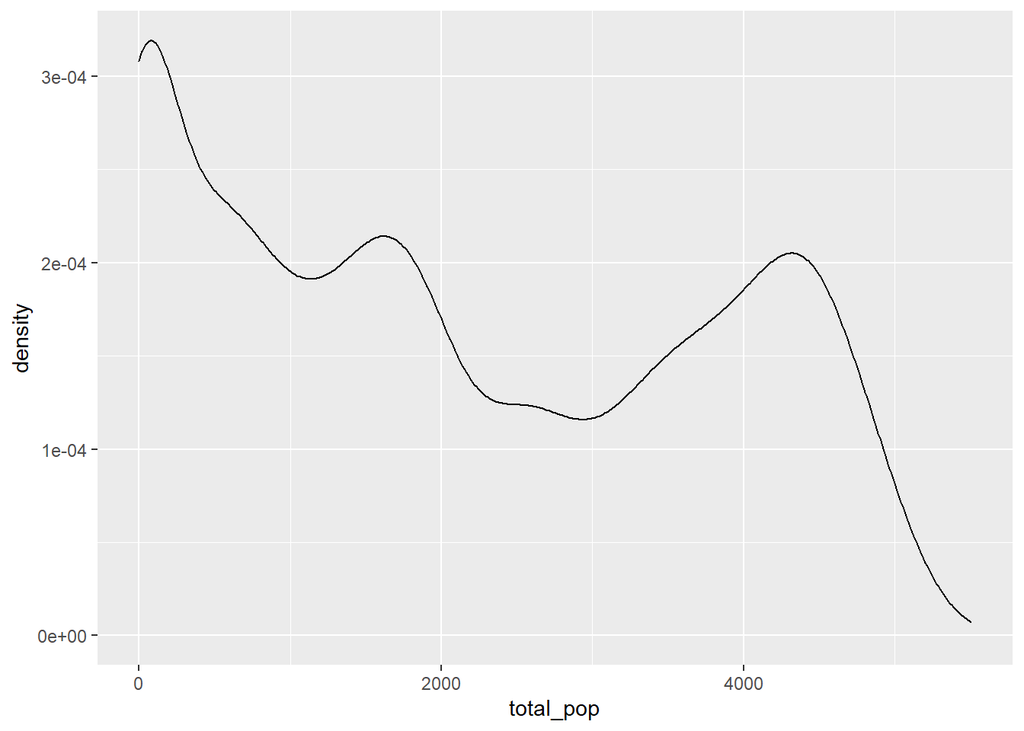

```r
sens_P = sobol2007(model = NULL,X1, X2, nboot = 500)


wrapper = function(n, initialP, fertility, survivorship,
                   habitat_init_funding, habitata_maint_funding, pred_funding,
                   raven_min, raven_lim,falcon_min, falcon_lim,
                   func) {

  area = habitat_area(1, init_funding = habitat_init_funding, maint_funding = habitata_maint_funding, n_time=n)

  raven_p = raven_pop(n, P0=80, K=160, pred_mgmt_funding=pred_funding,
                      min=raven_min ,limit=raven_lim)

  falcon_p = falcon_pop(n, P0=50, K=100, pred_mgmt_funding=pred_funding,
                      min=falcon_min ,limit=falcon_lim)

  predatorpop_matrix = list(raven_p, falcon_p)
  predatorpop_matrix = predatorpop_matrix %>% unlist() %>% matrix(ncol=n, byrow = T) # row1= raven, row2=falcon

  snpl_p = snpl_pop3(fertility, survivorship, initialP, nstep=n, K=5000, predatorpop_matrix, area)

  return(snpl_p$total_pop)
}


allresults = mapply(FUN=wrapper,
                   habitat_init_funding=sens_P$X$habitat_init_funding,
                   habitata_maint_funding=sens_P$X$habitata_maint_funding,
                   pred_funding=sens_P$X$pred_funding,
                   raven_min=sens_P$X$raven_min, raven_lim=sens_P$X$raven_lim,
                   falcon_min=sens_P$X$falcon_min, falcon_lim=sens_P$X$falcon_lim,
                   MoreArgs=list(n=n_years, initialP=ini, fertility=fert_snpl, survivorship=surv_snpl,
                                 func=snpl_pop3)
                   )

ggplot(data.frame(total_pop=allresults), aes(x=total_pop))+geom_density()
```

```r
sens_P_totalpop = sensitivity::tell(sens_P, allresults)
sens_P_totalpop$S
```

```
##                            original          bias std. error    min. c.i.
## habitat_init_funding    0.000000000  0.0000000000 0.00000000  0.000000000
## habitata_maint_funding  0.000000000  0.0000000000 0.00000000  0.000000000
## pred_funding            0.818050981  0.0068192975 0.06576703  0.671098339
## raven_min              -0.009549406 -0.0001107414 0.01347284 -0.034494462
## raven_lim               0.015235952 -0.0002723938 0.01152194 -0.008061415
## falcon_min              0.041402839 -0.0001780230 0.02884360 -0.016618291
## falcon_lim              0.031553705  0.0011603945 0.02671119 -0.019509435
##                         max. c.i.
## habitat_init_funding   0.00000000
## habitata_maint_funding 0.00000000
## pred_funding           0.93234626
## raven_min              0.01821112
## raven_lim              0.03934944
## falcon_min             0.09629200
## falcon_lim             0.08532847
```

```r
sens_P_totalpop$T
```

```
##                            original          bias std. error   min. c.i.
## habitat_init_funding   0.0000000000  0.000000e+00 0.00000000  0.00000000
## habitata_maint_funding 0.0000000000  0.000000e+00 0.00000000  0.00000000
## pred_funding           0.7813757662  3.088349e-03 0.05785552  0.66165877
## raven_min              0.0545318153 -5.058425e-05 0.01707529  0.01819110
## raven_lim              0.0002565004  5.582316e-04 0.01218669 -0.02561915
## falcon_min             0.2066764701  7.607042e-04 0.03430725  0.13343208
## falcon_lim             0.1748593251  2.557772e-04 0.02961730  0.12127584
##                         max. c.i.
## habitat_init_funding   0.00000000
## habitata_maint_funding 0.00000000
## pred_funding           0.89522901
## raven_min              0.08755765
## raven_lim              0.02234195
## falcon_min             0.27174927
## falcon_lim             0.24051002
```

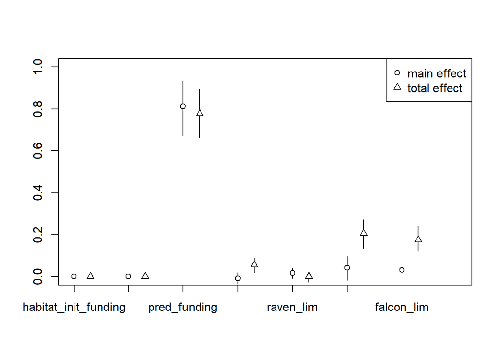

```r
plot(sens_P_totalpop)
```

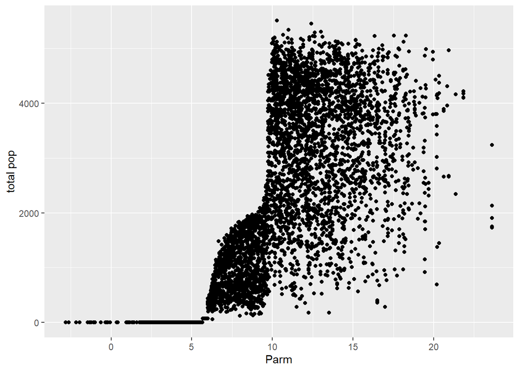

```r
tmp = cbind.data.frame(sens_P_totalpop$X, total_pop=sens_P_totalpop$y)
ggplot(tmp, aes(pred_funding, total_pop))+geom_point()+labs(x="Parm",y="total pop")
```

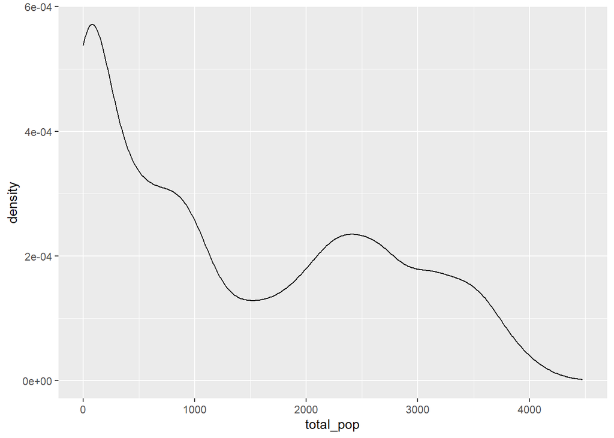

```r
# Run the Sobol sensitivity analysis on 25-year mean values for initial parameters.

source("../R/predator_mgmt.R")
source("../R/snpl.R")
source("../R/habit.R")

F_adult = 5.25*0.6 # 1156/220 # 5.25 eggs per adult, M to F ratio of 0.6 (3 males to 2 females). represents number eggs per female; adjust for diff sex ratios
ini = c(1156,588,134,220)
n_years = 15

np = 1000

p_egg = 0.459  # Hatch rate; 25-year mean hatch rate, 45.9%
p_chick = 0.363 # Fledge rate; 25-year mean fledge rate, 36.3%
p_fledge = 0.25 # First Winter Survival, assume 25-50% make it; Assess low estimate. Adjust this value as needed.
p_adult = 0.50 # Adult survivorship, assume 50-75% make it; Assess low estimate. Adjust this value as needed.

fert_snpl = c(0,0,0,F_adult)
surv_snpl = c(p_egg,p_chick,p_fledge,p_adult)


habitat_init_funding = rnorm(mean = 200, sd = 50, n=np)
habitata_maint_funding = rnorm(mean = 50, sd = 20, n=np)
pred_funding = rnorm(mean = 10, sd = 4, n=np)
raven_min = runif(n=np, min = 0, max = 0.5)
raven_lim = runif(n=np, min = 0.5, max = 1)
falcon_min = runif(n=np, min =0, max = 0.5)
falcon_lim = runif(n=np, min =0, max = 1)
X1 = cbind.data.frame(habitat_init_funding=habitat_init_funding, habitata_maint_funding=habitata_maint_funding,
                      pred_funding=pred_funding, raven_min=raven_min, raven_lim=raven_lim,
                      falcon_min=falcon_min, falcon_lim=falcon_lim)

habitat_init_funding = rnorm(mean = 200, sd = 10, n=np)
habitata_maint_funding = rnorm(mean = 30, sd = 5, n=np)
pred_funding = rnorm(mean = 10, sd = 4, n=np)
raven_min = runif(n=np, min = 0, max = 0.5)
raven_lim = runif(n=np, min = 0.5, max = 1)
falcon_min = runif(n=np, min =0, max = 0.5)
falcon_lim = runif(n=np, min =0, max = 1)
X2 = cbind.data.frame(habitat_init_funding=habitat_init_funding, habitata_maint_funding=habitata_maint_funding,
                      pred_funding=pred_funding, raven_min=raven_min, raven_lim=raven_lim,
                      falcon_min=falcon_min, falcon_lim=falcon_lim)

library(sensitivity)

sens_P = sobol2007(model = NULL,X1, X2, nboot = 500)


wrapper = function(n, initialP, fertility, survivorship,
                   habitat_init_funding, habitata_maint_funding, pred_funding,
                   raven_min, raven_lim,falcon_min, falcon_lim,
                   func) {

  area = habitat_area(1, init_funding = habitat_init_funding, maint_funding = habitata_maint_funding, n_time=n)

  raven_p = raven_pop(n, P0=80, K=160, pred_mgmt_funding=pred_funding,
                      min=raven_min ,limit=raven_lim)

  falcon_p = falcon_pop(n, P0=50, K=100, pred_mgmt_funding=pred_funding,
                      min=falcon_min ,limit=falcon_lim)

  predatorpop_matrix = list(raven_p, falcon_p)
  predatorpop_matrix = predatorpop_matrix %>% unlist() %>% matrix(ncol=n, byrow = T) # row1= raven, row2=falcon

  snpl_p = snpl_pop3(fertility, survivorship, initialP, nstep=n, K=5000, predatorpop_matrix, area)

  return(snpl_p$total_pop)
}


allresults = mapply(FUN=wrapper,
                   habitat_init_funding=sens_P$X$habitat_init_funding,
                   habitata_maint_funding=sens_P$X$habitata_maint_funding,
                   pred_funding=sens_P$X$pred_funding,
                   raven_min=sens_P$X$raven_min, raven_lim=sens_P$X$raven_lim,
                   falcon_min=sens_P$X$falcon_min, falcon_lim=sens_P$X$falcon_lim,
                   MoreArgs=list(n=n_years, initialP=ini, fertility=fert_snpl, survivorship=surv_snpl,
                                 func=snpl_pop3)
                   )

ggplot(data.frame(total_pop=allresults), aes(x=total_pop))+geom_density()
```

```r
sens_P_totalpop = sensitivity::tell(sens_P, allresults)
sens_P_totalpop$S
```

```
##                          original          bias  std. error    min. c.i.
## habitat_init_funding   0.00000000  0.000000e+00 0.000000000  0.000000000
## habitata_maint_funding 0.00000000  0.000000e+00 0.000000000  0.000000000
## pred_funding           0.75923501 -4.582511e-03 0.063291649  0.624694462
## raven_min              0.04116338 -8.148191e-05 0.014986566  0.012447534
## raven_lim              0.01223594 -4.187418e-04 0.009749762 -0.008226816
## falcon_min             0.07160398  2.289519e-03 0.030316517  0.013686332
## falcon_lim             0.06965040 -2.876043e-04 0.026809741  0.009496069
##                         max. c.i.
## habitat_init_funding   0.00000000
## habitata_maint_funding 0.00000000
## pred_funding           0.88222029
## raven_min              0.06993439
## raven_lim              0.02999810
## falcon_min             0.12707518
## falcon_lim             0.11836918
```

```r
sens_P_totalpop$T
```

```
##                           original          bias std. error    min. c.i.
## habitat_init_funding    0.00000000  0.000000e+00 0.00000000  0.000000000
## habitata_maint_funding  0.00000000  0.000000e+00 0.00000000  0.000000000
## pred_funding            0.80475637  3.336198e-03 0.06107085  0.681244246
## raven_min              -0.01439478  5.268641e-05 0.02035561 -0.057889325
## raven_lim               0.02065354  4.178825e-04 0.01284798 -0.005886797
## falcon_min              0.20696535 -1.896801e-03 0.03696028  0.129031129
## falcon_lim              0.12118269  1.634739e-03 0.02719538  0.063274254
##                         max. c.i.
## habitat_init_funding   0.00000000
## habitata_maint_funding 0.00000000
## pred_funding           0.92723700
## raven_min              0.02448376
## raven_lim              0.04571643
## falcon_min             0.28055499
## falcon_lim             0.17130190
```

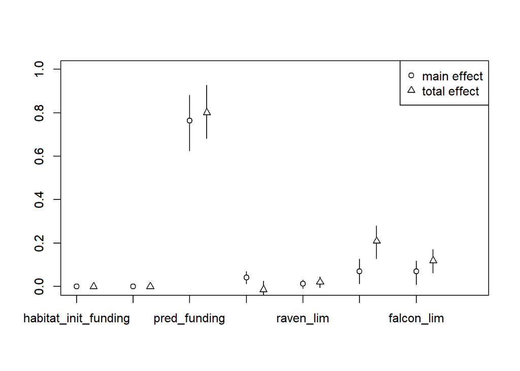

```r
plot(sens_P_totalpop)
```

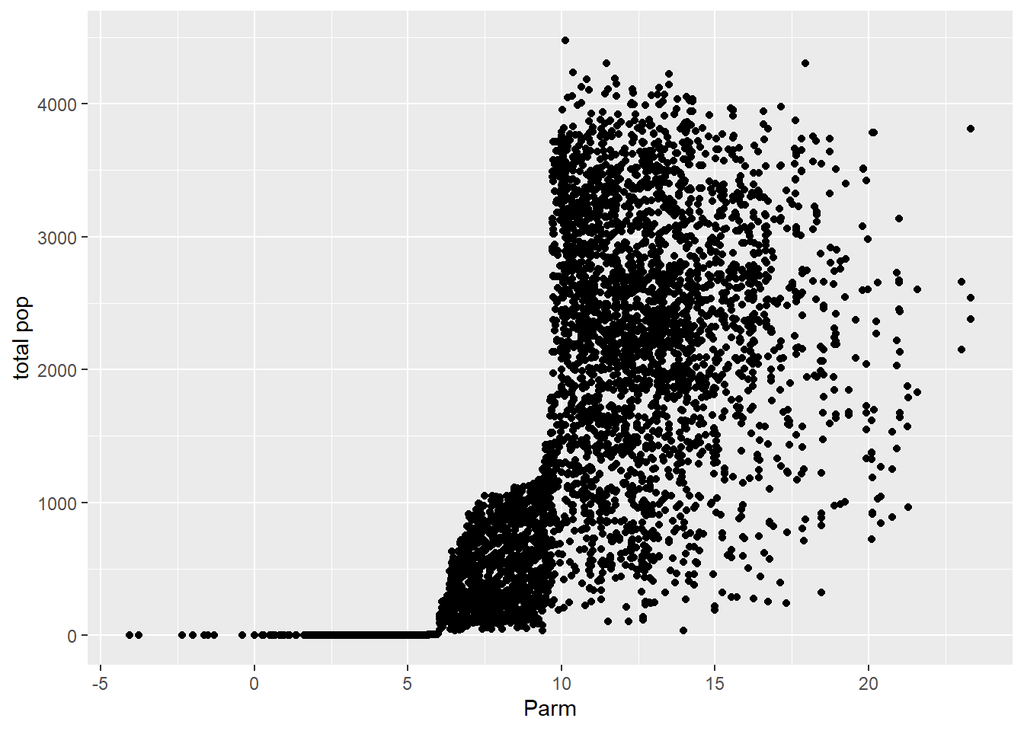

```r
tmp = cbind.data.frame(sens_P_totalpop$X, total_pop=sens_P_totalpop$y)
ggplot(tmp, aes(pred_funding, total_pop))+geom_point()+labs(x="Parm",y="total pop")
```

To test the sensitivity of the plover population to the different management actions we ran a Sobol sensitivity analysis on both the 2019 and the 25-year mean values for the initial parameters. In both tests, plover population was the most sensitive to changes in predator management funding. Theses models only account for a small portion of the factors that influence snowy plover productivity and survivorship. We addressed predator management and habitat restoration because these are the factors that wildlife managers are able to control with some funding and expertise. They are also the factors that are most easily monitored. Food resources likely contribute ore to plover survivorship than is expected, however, it is challenging to collect reliable field data on this metric, attribute mortality to food resource issues, and subsequently do anything about it in the presence of all other management factors. Within our submodels, the uncertainty in the funding parameters corresponds with the variability in funding for wildlife conservation projects between years. In reality, the level of finding available often impacts whether or not the management action can even take place. Our model tests a range of funding, but actual management may incorporate a lower funding threshold. We did not incorporate this detail into our model for the sake of model complexity. Our results further highlight the need for predator management in threatened species recovery programs. Since the success of management action is reliant entirely on funding, this model may be useful supporting documentation in project and funding proposals. It may also aid in determining the most effective use of potentially limited funding.